# Installing R and RStudio

This document walks you through installing R and RStudio on your personal computer.

In the instructions below, anywhere it says (version), there will be a series of numbers such as `3.5.1`. The specific version does not matter, but we want to always use the most recent one.

## Installing R

### Windows

1. Go to the [Windows Installers page](https://cran.r-project.org/bin/windows/base/).
   - Click `Download R (version)` to download: Whatever version is listed will be the most current.
2. Run the installer.
   - If the installer asks, grant it administrative privileges to install.
   - Follow the on-screen instructions.
   - You do not need to change any default values unless you have a good reason.
3. Once it completes, R is installed!
   - There may now be R icons on your desktop or start menu, but we typically do not use R directly.

### MacOS

1. Go to the [MacOS Installers page](https://cran.r-project.org/bin/macosx/).
   - Scroll to “Latest release”
   - Click `R-(version).pkg` to download: Whatever version is listed will be the most current.
2. Run the installer.
   - Follow the on-screen instructions.
   - You do not need to change any default values unless you have a good reason.
3. Once it completes, R is installed!
   - There may now be R icons on your desktop or start menu, but we typically do not use R directly.
4. Browse to the [XQuartz download page](https://www.xquartz.org/)
   - Click `XQuartz-(version).dmg` to download.
5. Run XQuartz installer.
   - XQuartz is needed to create windows to display many types of R graphics: this used to be included in MacOS until version 10.8 but now must be downloaded separately.

## Installing RStudio

### Windows

1. Go to the [Installers page](https://www.rstudio.com/products/rstudio/download/#download).
   - Scroll to “Installers for Supported Platforms”
   - Click `RStudio (version) - Windows Vista/7/8/10` to download: Whatever version is listed will be the most current.
2. Run the installer.
   - If the installer asks, grant it administrative privileges to install.
   - Follow the on-screen instructions.
   - You do not need to change any default values unless you have a good reason.
3. Once it completes, RStudio is installed!
   - We will use the RStudio icon to load RStudio and use R.
4. Open RStudio and verify it loads.
   - If there are any problems, email me at clanfear@uw.edu

### MacOS

1. Go to the [Installers page](https://www.rstudio.com/products/rstudio/download/#download).
   - Scroll to “Installers for Supported Platforms”
   - Click `RStudio (version) - MacOS X 10.6+ (64-bit)` to download: Whatever version is listed will be the most current.
2. Run the installer.
   - Follow the on-screen instructions.
   - You do not need to change any default values unless you have a good reason.
3. Once it completes, RStudio is installed!
   - We will use the RStudio icon to load RStudio and use R.
4. Open RStudio and verify it loads.
   - In the bottom-left panel of RStudio, you should see something vaguely like the image below.
   - If there are any problems, email me at clanfear@uw.edu

When you open RStudio, you should see something similar to this in the bottom-left:

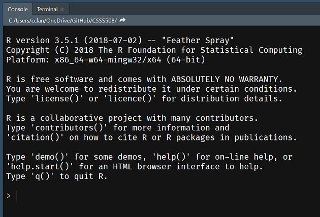

If so, your installation was successful!